# Chapter 2: Inference using t-Distributions

Loren

08/17/2014

## Bumpus sparrows

59 sparrows were collected after a storm. Some perished and some survived. (Don’t ask me how the survivors were collected). The length of each bird’s HUMERUS was measured.

```
##
## PERISHED SURVIVED
##       24       35
```

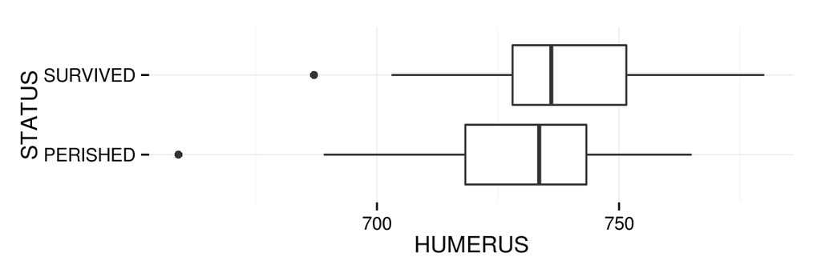

The two groups have about the same spread.

```r
(bt <- t.test(HUMERUS ~ STATUS, data=case0201))
```

```
##
##  Welch Two Sample t-test
##
## data:  HUMERUS by STATUS
## t = -1.721, df = 43.82, p-value = 0.09236
## alternative hypothesis: true difference in means is not equal to 0
## 95 percent confidence interval:
##  -21.895   1.728
## sample estimates:
## mean in group PERISHED mean in group SURVIVED
##                  727.9                  738.0
```

No convincing evidence of a difference (p.val = 0.0924), and removing the outliers would not increase the significance either.

## Schizophrenic Identical Twins

We have 15 pairs of identical twins. In each pair, one twin is affected by schizophrenia and the other is not.

In almost all pairs, the the unaffected twin has higher volume:

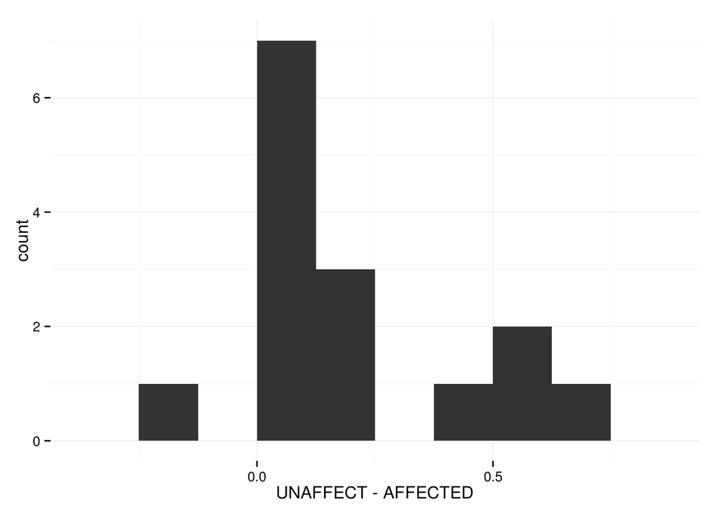

```r
(test <- with(case0202, t.test(UNAFFECT, AFFECTED, paired=T)))
```

```
##
##  Paired t-test
##
## data:  UNAFFECT and AFFECTED
## t = 3.229, df = 14, p-value = 0.006062
## alternative hypothesis: true difference in means is not equal to 0
## 95 percent confidence interval:
##  0.0667 0.3306
## sample estimates:
## mean of the differences
##                  0.1987
```

We have a significant difference (p-val = 0.0061) in brain volume, with an average difference of 0.1987. The 95% confidence interval for the difference is 0.0667 to 0.3306.

# Conceptual Exercises

1. If the dead birds were measured while they were dead, the experimenter could have been biased.
2. Because it’s not what we’re interested in?
3. “Shape of a histogram of the sample” – false. The histogram will be shaped like the population.
4. True

# Computational Exercises

## 12. Marijuana during pregnancy

```r
diff <- 280 # users - nonusers (birth weight)
se.diff <- 46.66
deg.free <- 1095
t.stat <- (diff - 0) / se.diff
```

1. 95% confidence interval for the difference between means:

```r
half.interval <- qt(.975,deg.free) * se.diff
c(-half.interval, half.interval) + diff
```

```
## [1] 188.4 371.6
```

2. 90% confidence interval for the difference between means:

```r
half.interval <- qt(.95,deg.free) * se.diff
c(-half.interval, half.interval) + diff
```

```
## [1] 203.2 356.8
```

3. 2-sided p-value for null hypothesis:

```r
2 * pt(-t.stat, deg.free)
```

```
## [1] 2.665e-09
```

## 13. Fish Oil and Blood Pressure

1. Group averages of BP:

```
## DIET: fishoil
## [1] 6.571
## --------------------------------------------------------
## DIET: regularoil
## [1] -1.143
```

2. pooled estimate of standard deviation:

```r
(sizes <- table(ex0213$DIET))                # the group sizes
```

```
##
##    fishoil regularoil
##          7          7
```

```r
(sds <- with(ex0213, by(BP, DIET, FUN=sd)))  # the group standard deviations
```

```
## DIET: fishoil
## [1] 5.855
## --------------------------------------------------------
## DIET: regularoil
## [1] 3.185
```

```r
(sp <- sqrt(sum((sizes - 1) * sds^2) / (sum(sizes -1)))) # the pooled standard deviation
```

```
## [1] 4.713
```

3. SE(mean1 - mean2):

```r
(se <- sp * sqrt(sum(1/sizes)))
```

```
## [1] 2.519
```

4. d.f. associated with sp is 12. The 97.5-th percentile of the t-dist with this degree of freedom is 2.1788.

# Data Problems

## 21. Bumpus sparrow weight

We have the weights of 59 sparrows, and whether they survived or not:

```
##   WEIGHT   STATUS
## 1   24.5 survived
## 2   26.9 survived
## 3   26.9 survived
## 4   24.3 survived
## 5   24.1 survived
## 6   26.5 survived
```

Group sizes, boxplot, and t-test:

```
## perished survived
##       24       35
```

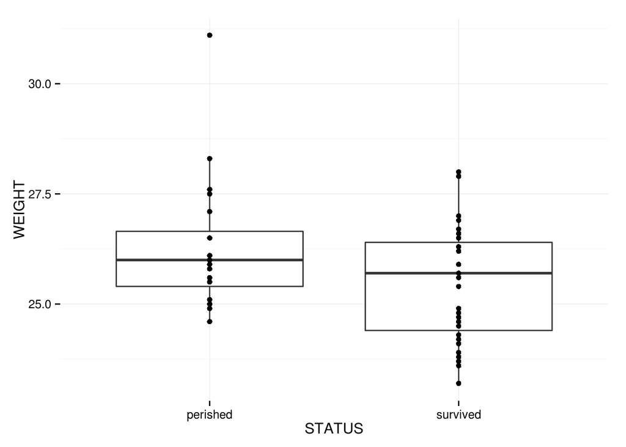

```
##
##  Welch Two Sample t-test
##
## data:  WEIGHT by STATUS
## t = 2.205, df = 44.3, p-value = 0.03266
## alternative hypothesis: true difference in means is not equal to 0
## 95 percent confidence interval:
##  0.07011 1.55417
## sample estimates:
## mean in group perished mean in group survived
##                  26.28                  25.46
```

T-test without “outlier”:

```
##
##  Welch Two Sample t-test
##
## data:  WEIGHT by STATUS
## t = 1.946, df = 52.05, p-value = 0.05707
## alternative hypothesis: true difference in means is not equal to 0
## 95 percent confidence interval:
##  -0.01877  1.22349
## sample estimates:
## mean in group perished mean in group survived
##                  26.07                  25.46
```

Whether the difference is “significant” (at the 0.05 level) depends on that one data point, so it would be a very weak conclusion.

## 23. Speed limits and traffic fatalities

For each state, we have whether it raised its speed limit (over 55) in 1996, and the percentage change in traffic fatalities from 1995 to 1996.

```
##               STATE INCREASE FATALITIESCHANGE
## 1            Alaska       No            -29.0
## 2       Connecticut       No             -4.4
## 3 Dist. of Columbia       No            -80.0
## 4            Hawaii       No            -25.0
## 5           Indiana       No            -13.2
## 6          Kentucky       No              3.4
```

```
##
##  No Yes
##  19  32
```

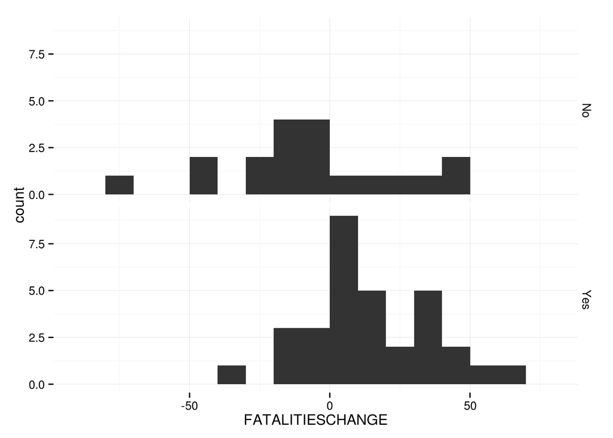

So, we have most of the states increasing their speed limit, and the change in fatalities in seems to be higher among states that increased their speed limit. Yes, we have a significant t-test:

```
##
##  Welch Two Sample t-test
##
## data:  FATALITIESCHANGE by INCREASE
## t = -2.772, df = 28.25, p-value = 0.009747
## alternative hypothesis: true difference in means is not equal to 0
## 95 percent confidence interval:
##  -38.800  -5.833
## sample estimates:
##  mean in group No mean in group Yes
##            -8.563            13.753
```

The confidence interval is (-38.7995, -5.833).